# Introduction to BioPython

[BioPython](https://biopython.org/) is a set of freely available tools for biological computation written in Python by an international team of developers. It is a distributed collaborative effort part of the Open Bioinformatics Foundation (OBF).

This notebook was inspired by the BioPython notebooks provided [here](https://github.com/tiagoantao/biopython-notebook).

```python
# uncomment the below to install dependencies for colab
#!pip install biopython
#!pip install py3Dmol
#!pip install pymsaviz
```

## Sequence Objects

Biopython deals with sequences using the `Seq` object. Sequences are essentially strings of letters like AGTACACTGGT, but the difference between `Seq` objects and standard Python strings is that they have different methods for performing biologically relevant methods.

```python
from Bio.Seq import Seq

# instantiating a Seq
my_seq = Seq("GATCG")

# print enumerated sequence
for index, letter in enumerate(my_seq):
    print(index, letter)

# get length of sequence
print(len(my_seq))
```

```
0 G
1 A
2 T
3 C
4 G
5
```

You can access elements of the sequence in the same way as for strings (a list of characters)

```python
print(my_seq[0]) #first nucleotide
print(my_seq[2]) #third nucleotide
print(my_seq[-1]) #last nucleotide
print(my_seq[:3]) #first to third nucleotide
```

```
G
T
G
GAT
```

The Seq object has a `.count()` method, just like a string. Note that this means that like a Python string, this gives a non-overlapping count:

```python
print("AAAA".count("A"))
print(Seq("AAAA").count("AA"))
```

```
4
2
```

For some biological uses, you may actually want an overlapping count (i.e. $3$ in this trivial example). When searching for single letters, this makes no difference:

```python
# instantiating a Seq
my_seq = Seq('GATCGATGGGCCTATATAGGATCGAAAATCGC')

# get length of sequence, number of G in sequence, GC%
print(len(my_seq))
print(my_seq.count("G"))
print(100 * (my_seq.count("G") + my_seq.count("C")) / len(my_seq))
```

```
32
9
46.875
```

While you could use the above snippet of code to calculate a GC%, note that the **Bio.SeqUtils** module has several GC functions already built. For example:

```python
from Bio.SeqUtils import gc_fraction

# calculate GC ratio
gc_fraction(my_seq)
```

```
0.46875
```

## Turning Seq objects into strings

If you really do just need a plain string, for example to write to a file, or insert into a database, then this is very easy to get:

```python
str(my_seq)
```

```
'GATCGATGGGCCTATATAGGATCGAAAATCGC'
```

You can also use the Seq object directly with the various string formatting approaches, such as f-strings:

```python
fasta_format_string = f">Name\n{my_seq}\n"
print(fasta_format_string)
```

```
>Name
GATCGATGGGCCTATATAGGATCGAAAATCGC
```

## Transcription and Translation

Biological transcription works from the template strand, doing a reverse complement (TACC -> GGTA) to give the mRNA. However, in Biopython we typically work directly with the coding strand because this means we can get the mRNA sequence just by switching (TACC -> UACC).

|  | DNA coding strand (Crick strand, strand +1) |  |
| --- | --- | --- |
| 5' | ATGGCCATTGTAATGGGCCGCTGAAAGGGTGCCCGATAG | 3' |
| 3' | TACCGGTAACATTACCCGGCGACTTTCCCACGGGCTATC | 5' |
|  | DNA template strand (Watson strand, strand -1) |  |
|  | **Transcription** |  |
| 5' | AUGGCCAUUGUAAUGGGCCGCUGAAAGGGUGCCCGAUAG} | 3' |
|  | Single stranded messenger RNA |  |

```python
# Instantiating a Seq
coding_dna = Seq("ATGGCCATTGTAATGGGCCGCTGAAAGGGTGCCCGATAG")
print(coding_dna)

# getting reverse complement
template_dna = coding_dna.reverse_complement()
print(template_dna)
```

```
ATGGCCATTGTAATGGGCCGCTGAAAGGGTGCCCGATAG
CTATCGGGCACCCTTTCAGCGGCCCATTACAATGGCCAT
```

These should match the figure above - remember by convention nucleotide sequences are normally read from the 5' to 3' direction, while in the figure the template strand is shown reversed.

Now let's transcribe the coding strand into the corresponding mRNA, using the Seq object's built in `.transcribe()` method:

```python
messenger_rna = coding_dna.transcribe()
messenger_rna
```

```
Seq('AUGGCCAUUGUAAUGGGCCGCUGAAAGGGUGCCCGAUAG')
```

## Translation

Sticking with the same example discussed in the transcription section above, now let's translate this mRNA into the corresponding protein sequence - again taking advantage of one of the Seq object's biological methods:

```python
messenger_rna.translate()
```

```
Seq('MAIVMGR*KGAR*')
```

You can also translate directly from the coding strand DNA sequence:

```python
coding_dna.translate()
```

```
Seq('MAIVMGR*KGAR*')
```

You should notice in the above protein sequences that in addition to the end stop character (*), there is an internal stop as well. This is because we are using the default genetic code (NCBI's standard genetic code - table 1), but there are other translation tables (Genetic Codes) that we can use. Suppose we are instead dealing with a Mitochondrial sequence. We need to tell the translation function to use the relevant genetic code instead:

```python
coding_dna.translate(table="Vertebrate Mitochondrial")
```

```
Seq('MAIVMGRWKGAR*')
```

You can also specify the table using the NCBI table number which is shorter, and often included in the feature annotation of GenBank files:

```python
coding_dna.translate(table=2)
```

```
Seq('MAIVMGRWKGAR*')
```

Now, you may want to translate the nucleotides up to the first in frame stop codon, and then stop (as happens in nature):

```python
coding_dna.translate(to_stop=True)
```

```
Seq('MAIVMGR')
```

Notice that when you use the `to_stop` argument, the stop codon itself is not translated - and the stop symbol is not included at the end of your protein sequence.

You can even specify the stop symbol if you don't like the default asterisk:

```python
coding_dna.translate(table=2, stop_symbol="@")
```

```
Seq('MAIVMGRWKGAR@')
```

# Sequence annotation objects

The Sequence Record or [SeqRecord class](http://biopython.org/DIST/docs/api/Bio.SeqRecord.SeqRecord-class.html), defined in the [Bio.SeqRecord module](http://biopython.org/DIST/docs/api/Bio.SeqFeature.SeqFeature-class.html) allows higher level features such as identifiers and features (as SeqFeature objects) to be associated with the sequence, and is used throughout the sequence input/output interface Bio.SeqIO to read and write FASTA files.

```python
from Bio.SeqRecord import SeqRecord
```

## The SeqRecord Object

The SeqRecord class itself is quite simple, and offers the following information as attributes:

| attribute | description |
| --- | --- |
| .seq | The sequence itself, typically a Seq object. |
| .id | The primary ID used to identify the sequence - a string. In most cases this is something like an accession number. |
| .name | A 'common' name/id for the sequence - a string. In some cases this will be the same as the accession number, but it could also be a clone name. I think of this as being analogous to the LOCUS id in a … |
| .description | A human readable description or expressive name for the sequence - a string. |
| .letter_annotations | Holds per-letter-annotations using a (restricted) dictionary of additional information about the letters in the sequence. The keys are the name of the information, and the information is contained in … |
| .annotations | A dictionary of additional information about the sequence. The keys are the name of the information, and the information is contained in the value. This allows the addition of more 'unstructured' info… |
| .features | A list of SeqFeature objects with more structured information about the features on a sequence (e.g. position of genes on a genome, or domains on a protein sequence). |
| .dbxrefs | A list of database cross-references as strings. |

## Creating a SeqRecord

Using a `SeqRecord` object is not very complicated, since all of the information is presented as attributes of the class. Usually you won't create a `SeqRecord` 'by hand', but instead use Bio.SeqIO to read in a sequence file for you and the examples below). However, creating `SeqRecord` can be quite simple.

### SeqRecord objects from scratch

To create a `SeqRecord` at a minimum you just need a `Seq` object:

```python
# instantiating Seq and SeqRecord
simple_seq = Seq("GATC")
simple_seq_r = SeqRecord(simple_seq)
```

Additionally, you can also pass the id, name and description to the initialization function, but if not they will be set as strings indicating they are unknown, and can be modified subsequently:

```python
# show id
simple_seq_r.id
```

```
'<unknown id>'
```

```python
# modifying id and description
simple_seq_r.id = "AC12345"
simple_seq_r.description = "Not a real sequence"

# retrieving description and sequence attributes
print(simple_seq_r.description)
print(simple_seq_r.seq)
```

```
Not a real sequence
GATC
```

Including an identifier is very important if you want to output your SeqRecord to a file. You would normally include this when creating the object:

```python
simple_seq = Seq("GATC")
simple_seq_r = SeqRecord(simple_seq, id="AC12345")
```

As mentioned above, the SeqRecord has an dictionary attribute annotations. This is used for any miscellaneous annotations that doesn't fit under one of the other more specific attributes. Adding annotations is easy, and just involves dealing directly with the annotation dictionary:

```python
simple_seq_r.annotations["evidence"] = "None"
print(simple_seq_r.annotations)
print(simple_seq_r.annotations["evidence"])
```

```
{'evidence': 'None'}
None
```

Working with per-letter-annotations is similar, letter_annotations is a dictionary like attribute which will let you assign any Python sequence (i.e. a string, list or tuple) which has the same length as the sequence:

```python
simple_seq_r.letter_annotations["phred_quality"] = [40, 40, 38, 30]
print(simple_seq_r.letter_annotations)
print(simple_seq_r.letter_annotations["phred_quality"])
```

```
{'phred_quality': [40, 40, 38, 30]}
[40, 40, 38, 30]
```

The dbxrefs and features attributes are just Python lists, and should be used to store strings and SeqFeature objects (discussed later) respectively.

## Obtain and Parse Sequences

### Getting Nucleotide Sequences

```python
from Bio import SeqIO
from Bio import Entrez
```

To start we will use the [`esearch`](https://biopython.org/docs/1.76/api/Bio.Entrez.html#Bio.Entrez.esearch) function to retreive a list of primary ids paired to the **'IdList'** key, which we will later use in `efetch`.

We will carry out a search of the 'assembly' database at NCBI using the term 'Escherichial coli' as the search query and use the optional parameter of `retmax` to ask NCBI to retrieve up to the first 10 results.

Additional parameters and explanations can be found [here](https://www.ncbi.nlm.nih.gov/books/NBK25499/#chapter4.ESearch).

```python
# Set email
Entrez.email = 'A.N.Other@example.com'

# The line below carries out the search
with Entrez.esearch(db="assembly", term="Escherichial coli", retmax=10) as handle:
    # converts the returned information from NCBI into a form we can use
    result = Entrez.read(handle)

# formatting dictionary for readability using json library
import json
print(json.dumps(result, indent=2))
```

```
{
  "Count": "321898",
  "RetMax": "10",
  "RetStart": "0",
  "IdList": [
    "67876158",
    "67875998",
    "67875898",
    "67875878",
    "67875758",
    "67875738",
    "67484298",
    "67484218",
    "67454018",
    "67453998"
  ],
  "TranslationSet": [],
  "TranslationStack": [
    {
      "Term": "coli[All Fields]",
      "Field": "All Fields",
      "Count": "321898",
      "Explode": "N"
    },
    "GROUP"
  ],
  "QueryTranslation": "coli[All Fields]",
  "ErrorList": {
    "FieldNotFound": [],
    "PhraseNotFound": [
      "Escherichial"
    ]
  }
}
```

Now, using the primary id results accessed by `result["IdList"]` we can fetch the entrez records in a requested format. Valid arguments for the parameters `rettype` and `retmode` can be found [here](https://www.ncbi.nlm.nih.gov/books/NBK25499/table/chapter4.T._valid_values_of__retmode_and/?report=objectonly).

From the nucleotide/nuccore database we are fetching the GenBank flat file for the records that match the given list of ids:

```python
# fetch query
with Entrez.efetch(db="nucleotide", id=result["IdList"], rettype="gb", retmode="text") as handle:

    # takes the handle and returns a SeqRecord iterator
    record_iterator = SeqIO.parse(handle, "gb")

    # fasta format
    for record in record_iterator:
        print(record.format("fasta"))
```

```
>DR131246.1 49234807 Drosophila pseudoobscura embryonic cDNA library Drosophila pseudoobscura cDNA clone O13 5', mRNA sequence
GGCACGAGGATTAAGTATTGAGTTCGAGGTTATCTTCCCTTTTAGGGTTGTTTACGTTGC
CGCTGACTTTGCCCCCAGTCTTTGCATCGCTAATCGCCACTGATTGCCACCAGGCGGACT
TTAAGTGCAGTTGAAAGTGAAACGGTGGTGGAGAATGCTGGATGTGATTGCACTGCTGTT
GATTACCCTCGCCATTGGCTTTTGGTATGTGCGCACGCGGCTGAGCTACTGGGCCAGGCG
CGGGATCGGGCATGTCAGGCCCACCTTTCCCATGGGTAACATGGATGGGCTTCGCAGGAC
AAAGCATTTCAAGGACATTGTGACGCCGCTGTACGAACGGTTTAAGGACAGCGGAGCGCC
CTTTGCCGGCATCTACATGATGCTGCGGCCTGTGGTTTTGGTCCTGGACCTGGATCTGGC
TAAGGAGGTGTTGATCAGGGACTTTGCGAACTTTGAGGATCGCGGCATGTACCACAATGA
ACGGGACGATCCTCTGACCGGCCACCTCTTTCGCATTGATGGACCCAAGTGGCGGCCCCT
GCGCCACAAGATGTCCCCCACGTTCACTTCGGGCAAGATGAAGTTCATGTTCCCCACCAT
ATGCGAGGTGGGCGTGGATTTGGCCGAGGTCTGCGGCGAGCTGGCAGCGAATGCCATCTG
CGGCATCCTGGAGATCAGTGACCTCATGGGCAGATACACCTCCGACGTGATTGGCCGCTG
TGTATTCGGCCTGGAGTGCAACGGATTGCGGAACCCCGAAGCCCAGTTTGCCGTAATGGG
TCGACGGGCCTTCACCGAACGACGCCACAACCAGCTGATCGATGGCTTCATCGAGAGCTT
CCCCGACCTGGCCCGCCCGCTGCGAATGTGCCAGATCCATCAGGACATCACTGACTTTTA
CCTGGGTATTGTGAAGGAGACCGTGAAACTGAGGGAGGAACAGGGAAATGGTCAGGAACG
ATTTCATGAATCCTTCTCATCGAAATGGAACCATCCCCGGCAAGCTCACCCCTAAAGGAA
AAGGGCTGCCCAAGGCATTTCATCTTCCTTTGCGGGCGGGGTTTCAAAACTTTTCGGCCT
TCGACCC

>DR131031.1 49231332 Drosophila pseudoobscura embryonic cDNA library Drosophila pseudoobscura cDNA clone M15 5', mRNA sequence
GGCCGAGGACCGAATCCGAGAACCGCGCCCCCTTAAGGGACCCCGAGNCGNCNTGCCNCG
GNTCCCCTAAAAAGCGGNGGCGGCCGCNCCACTGGCTTTGCCCNCANCNACGACACCCTG
GACTTTGCCAAGAAGTTCCTTCCCAAGTACCGTCTGGCCCGTCACGGTCTCTTCGAGCAG
AAGAAACAGACCCGCAAGCAGCGCAAGGAACGTCGCAACAGGATGAAGAAGGTCCGTGGT
ACCGCCAAGGCCAAGATTGGTGCTGGCAAGAAGTAAATTCTCTGACAAATCCTGAGTGCG
TGTGTGTTGTCGGCCTGCTGGAACGCTCACCGACAATTCCCAAAAGCAGCTGGTTATGCG
TTTTTTACACCTTTACACCAACAAACAAAGGACGAAACAAAATCAGTGTTTACTTTTGGA
GCGGCTTTTGTTTGTATACTAAGTAAATAAAACTCTAAAAGTAAAAAAAAAAAAAAAAAA
A

>DR131011.1 49247668 Drosophila pseudoobscura embryonic cDNA library Drosophila pseudoobscura cDNA clone K19 5', mRNA sequence
GCCGAGGGCCGGACATCTTATCTCTGTTGACAAAATCCCTTTAAGGCTGGNGGAAAAATT
ATCTCCGGCGGCGGGAACTCTTTTAGCCCCTGCCAGACAACTTATCTCTGTTGACGAAAT
ACGTCTCTCCGCTGGCGGAAAACTTATTTCCGGTGCCCTGAAATCTTTATCCGCTGCCGG
ACATCTTATCTCTGCTAACAAAATTCGTCTCTCCGCTGGCGAAAAACTTATCTCCGGTTG
CGGGAAATTTATATCCGCTGGCGGAAAACTTTTCTCTAGAGGGGGGAATTTATATCCCCT
GCCGGACAGCTTATCTCGGCTGACAAAATACGTCTCTCCGCTTGCAGAAAACATATCTCC
GGCGGCGAGAAATTTATATCCCCTGCCGGACATCTTATCTCGGCTGACAAAATACGTCTC
```

[output cut: 1072 more lines]

```
CAAGAGAATGCACTGGTCATAGCAAACATCCTCTTCGAACAACACAAGAGAAGACTCTAC
ACATGGACATCAACAGATGGTCAACACCGAAATCAGATTGATTATATTCTTTGCAGCCAA
AGATGGAGAAGCTCTATACAGTCAGCAAAAAGAAGACCAAGAGATAACTATGACTCAGAT
CATGAACTCCTTATTGCCAAATTCAGACTTAAATTGAAGAAAGTAGGGAAAACACTAGAC
CATTCAGGTATGACCTAAATCCAATCCCTTATGAATATACAGTGGAAGTGAGAAATAGAT
TTAAAGGACTAGATCTGATAGACAGAATGCCTGATGAACTTTGGATGGAGGTTCGTGATG
TTGTACAGGAGACAGGGATCAAGACCATCCCCATAGAAAAGAAATGCAAAAAAGCAAAAT
GGCTGTATGAGGAGGCCTTACAAACAGCTGTGAAAAGAAGAGAAGCAAAAAGCAAAGGAG
AAAAGGAAAGATATAAGCATCTGAATGCAGAGTTCCAAAGAATAGCAAGGAGAGATAAGA
AAGCCTTCCTCAGCGATCAATGCAAAGAAATAGAGGAAAACAACAGAATGGGAAAGACTA
GAGATCCCTTCAAGAAAATTAGAGATACCAAGGGAACATTTCATGCAAAGATGGGCACAA
TAAAGGACAGAAATGGTATGGACCTAACAGAAGCAGAAGATATTAAGAAGAGGTGGCAAG
AATACACAGAACTGTACAAAAAAAGATCTTCATGACCCAGATAATCACGATGGTGTGATC
ACTCACCTAGAGCCAGACATCCTGGAATGTGAAGTCAAGCGGGCCTTAGAAAGCATCACT
ATGAACAAAGCTAGAGGAGGTGATGGAATTCCAGTGGAGT
```

### Getting Protein Sequences

We will follow the same steps as above. First, using `esearch` to retreive the ids of interest.

```python
# The line below carries out the search of the protein database
with Entrez.esearch(db="protein", term="Escherichial coli", retmax=10) as handle:
    # converts the returned information from NCBI into a form we can use
    result = Entrez.read(handle)

# check out primary ids
result['IdList']
```

```
['2875145108', '2875145107', '2875145104', '2875145076', '2875145072', '2875145040', '2875145006', '2875144998', '2875144982', '2875144958']
```

Next, using `efetch` to get the protein sequences for those record ids.

```python
with Entrez.efetch(db="protein", id=result["IdList"], rettype="gb", retmode="text") as handle:
    record_iterator = SeqIO.parse(handle, "gb")

    for record in record_iterator:
        print(record.format("fasta"))
```

```
>WP_410110698.1 DNA topoisomerase, partial [[Ruminococcus] lactaris]
VERAGQISNFQKEKYFNVELDCDGIPAVKPKIFDPDEAEQLRSRCHGNEAIVTSVKETEK
KVKAPKLYDLTTLQREANRIYGMTAKQTLDTAQSLYEKKLITYPRTDSQYLTEDMEQTAR
NVVRQIYEKYQLTGPFDQPEQPDVKKVMNNSKVTDHHAIIPTMELASCHLDELKSWEEKI
LFLIAVHTVMAMSKDHIYQETEIEVECQGEIFKAKGKIVLQDGWKLFENCFKNKDRMAIV
DPNQEMKERMPKVTQGQTFYAVAAEKTEHFTSPPKPYSEDTLLAAMETAGNKEFDEDTEK
KGLGTPATRAGIIEKLIYSQYATRKGKQILPTDDGKVLVEILPDFLKSASMTAEWENQLL
LMEHGEIAPEQFMTGIKNMLTMMLNGCDAISEEETRRFQTRESIGTCPVCGSLVYESKTN
FYCSNHDCHFALWKDNRYLQSMEKTMDKKMAAEFLKNGCVHVKDLYSRKKNMYFEADLHM
DADETGRVNFSLSFPKKKPKNKSKKK

>WP_410110697.1 RtcB family protein [[Ruminococcus] lactaris]
MNALEIKGKVNTALCYAKVVEDEAIEQIRRMCDYAMTEGSQIRIMPDVHAGKGCTIGTTM
TITDKAVPNVVGVDIGCGMYTVNLGKDEIDFEKVDEAAHFIPSGREVWEGRQEKFDLTEL
RCYRELKDAKRLARSLGTLGGGNHFIEIDEAADGTKYLVIHSGSRNLGKQVAELYQKLAI
NLNRGYGEYLEKRDEIIRTYKEQGRKREIQDALKQLHWQVYESPTSMPEDLCYLEGIYLE
DYLHDVEICQAFARRSREKMAEVILERTVMTGSDAFHTIHNYIDTDEMILRKGAIAAHKG
EKVLIPINMKDGSILAIGKGNPEWNFSAPHGAGRIMSRTKAKNELNLDEYKKAMEGVYWI
GYN

>WP_410110694.1 A/G-specific adenine glycosylase, partial [[Ruminococcus] lactaris]
MKYERIEKAVFLERENRFVAYVELDGKREKVHVKNTGRCEELLIPGAEVYLQKSENEKRA
TLWDLIAVKKGERLVNLDSQIPNRCVEEWLQTGNLFKEIQCIRPEITYGDSRLDLYAEGD
GKKAFIEVKGVTLEEDGVCLFPDAPSERAVRHIEELIKAKKEGYEAILFFVIQMKEVRYF
TPNQKTQPEFAEALKRAKAAGVKILAYDCEVSKDEIRICDPVDVVLESPQMKETVPLIVE
WYRKNRRDLPWRKNINAYRVWISEIMLQQTRVEAVKPYYERFLSELPDIETLANVEEDKL
LKLWEGLGYYNRARNLKLAAQQIMEQYGGKFPETYEKIRELKGIGNYTAGAIGSFVYDLQ
KPAVDGNVFRVVSRILEDADDILKASTRKKVESLLEEVIPKESPGDFNQGLIELGAIVCL
PGGEPKCEICPVSHLCLAHRDGCELEYPVKKKAKERRVEKKTILRFCDNEEVAIRKRPDT
GLLAGLYEFPNVEGHLKQKEVIEYARSLGLTPVRVKKLPDAKHIFSHVEWQMKGYEVIVD
ELERELDQKIWSEQVIFA

>WP_410110666.1 LysM peptidoglycan-binding domain-containing protein [[Ruminococcus] lactaris]
MERQIPKNVRQIGNVSDSPKIYVEDYVDTFFAQLSDKYRNDPQKPLGAFLIGDFQTYEGE
DYVYIYGAIQMQELRVSGMEYLIDDETWKRAYEECKQFFEDGELIGWFVVRDDAEKEPGN
STVKQHKKSFPKKNTVFIICDPQEKEETYYVHKMNDLMEIGGHYTYYEKNPCMQDYMISS
RKKNGAVQTEVVEDKAAQNFRDLARKQGRRTRQKHQGNFVYAMSVGLVLVLVIMGVAMLN
NFNKIRKAQNQLEEVAGTINTVKDAGNSGNSNESNDPNGGQADDSEKGTADENTGAEKSN
SASDKKAEGDDGTSKNDTDGDASTNSSQAKNSQSDEVVEASAVPSSSTNGSDGVYVVERG
DTLAIISKKMYGDVTHVDAICRMNGLSNGNLIYIGQKLILP
```

[output cut: 33 more lines]

```
WLSMERIDKDTILNHFPNIYHHCLEEGYDVTKECIPVVPAQHYFMGGVWVDSDSKTSMDH
LFAVGETSCNGVHGANRLASNSLLESLVFAKRAAKKIGGEQV

>WP_410110572.1 FAD-binding protein, partial [[Ruminococcus] lactaris]
MKMKADAVIVGTGVGGLFSALNLPRDKKIIMITKSDLESSDSFLAQGGICMLHDEDDYDS
YFEDTMKAGHYENRKESVDIMIRSSREIIQDLIGYGVEFQKESDVPEGNSAEEGNQEKGR
EPETDKPLEEIYAFTREGAHSRPRILFHEDVTGKEITSKLLAQVKKLANVEIYEYTTMTD
IIVEDGVCRGIYAKDQNGQELEIYADNTIWASGGIGGRYQHSTNFPHLTGDALDISEKHG
IRLEHLDYVQIHPTTLYSTKPGRRFLISES

>WP_410110548.1 phosphoribosylglycinamide formyltransferase [[Ruminococcus] lactaris]
MLRVVVMVSGGGTNLQAILDAVDAGRITNTEIVGVISNNKNAYALTRAAEHGIKAECISP
KDYESRAEFNEALIGGVDSYQPDLVVLAGYLVVIPPEMIAKYRNRMINIHPSLIPAFCGT
GFYGLKVHEAALERGVKVVGATVHFVDEGTDTGPIILQKAVEVENGDTPEILQHRVMEQA
EWRILPKAIDLIANGRVKVEGRRTVIED
```

# Protein Parameters

When working with sequences, especially in ML models, it is important to extract some parameters that summarize them and that can be used, for instance, to make sure that your train/test/validation splits are comparable.

We can make use of `Bio.SeqUtils.ProtParam`, for example the methods contained within the [`ProteinAnalysis` class](https://biopython.org/docs/1.76/api/Bio.SeqUtils.ProtParam.html#Bio.SeqUtils.ProtParam.ProteinAnalysis), to extract these parameters and visualize them.

```python
from Bio.SeqUtils.ProtParam import ProteinAnalysis

# instantiate the protein sequence
protein_sequence = ProteinAnalysis("MAEGEITTFTALTEKFNLPPGNYKKPKLLYCSNGGHFLRILPDGTVDGT"
                    "RDRSDQHIQLQLSAESVGEVYIKSTETGQYLAMDTSGLLYGSQTPSEEC"
                    "LFLERLEENHYNTYTSKKHAEKNWFVGLKKNGSCKRGPRTHYGQKAILF"
                    "LPLPV")

# dict of the amino acid counts
print(protein_sequence.count_amino_acids())

# calculate molecular weight, naromaticity, instability_idex, isoelectric point
print("%0.2f" % protein_sequence.molecular_weight())
print("%0.2f" % protein_sequence.molecular_weight())
print("%0.2f" % protein_sequence.aromaticity())
print("%0.2f" % protein_sequence.instability_index())
print("%0.2f" % protein_sequence.isoelectric_point())

# the fraction of amino acids which tend to be in Helix, Turn or Sheet
sec_struc = protein_sequence.secondary_structure_fraction()
print(sec_struc)

epsilon_prot = protein_sequence.molar_extinction_coefficient()  # [reduced, oxidized]
print(epsilon_prot[0])  # with reduced cysteines
print(epsilon_prot[1])  # with disulfid bridges
```

```
{'A': 6, 'C': 3, 'D': 5, 'E': 12, 'F': 6, 'G': 14, 'H': 5, 'I': 5, 'K': 12, 'L': 18, 'M': 2, 'N': 7, 'P': 8, 'Q': 6, 'R': 6, 'S': 10, 'T': 13, 'V': 5, 'W': 1, 'Y': 8}
17103.16
17103.16
0.10
41.98
7.72
(0.32894736842105265, 0.28947368421052627, 0.3684210526315789)
17420
17545
```

```python
# creating a train and test set
train_sequences = ['MIQEKDKYVVASVTILESNQILDKGSIQTSGIELNYYMKYQKY',
             'MIQEKDKYVVASVTILESNQLLKEANSSGN',
             'MIQEKDKYVVASVTILESNQNSDVFIDLTNLTVEHKKLLN',
             'MIQEKDKYVVASVTILESNQVFDAMGFGGFLNINRKKFYNDL',
             'MIQEKDKYVVASVTILESNQVFFDSPEIKKLGLVTLKAKYD',
             'MIQEKDKYVVASVTILESNQFGMKRNILYKETKALRAK']
test_sequences = ['MIQEKDKYVVASVTILESNQILDKGSIQAAAALNYYMKYQKY',
             'MIQEKDKAAAAHHHHHHTILESNQLLKEANSSGN',
             'MIQEAAAAAASVTILHHHHHHHHESNQNSDVFIDLTNLTVEHKKLLN',
             'MIQEKDKYVVLLLLLLLSSSSSAAAAAAGFGGFLNINRKKFYNDL',
             'MIQEKDKYVVASVTILESNQVFFDSSSSSAAAAAAAKKLGLVTLKAKYD',
             'MIQEKDKYVVASVTILESNQFGMKRNILYKLLLLSSSSSSSSSKKKKKAAAAAAK']
```

```python
import pandas as pd

# a function to create a DataFrame of mean amino acid composition for a set of sequences
def calculate_mean_AA_composition(sequences):
    stats = []
    for sequence in sequences:
        protein_sequence = ProteinAnalysis(sequence)
        st = {k:v/len(sequence) for k,v in protein_sequence.count_amino_acids().items()}
        stats.append(st)
    df = pd.DataFrame.from_dict(stats).transpose()
    df = df.T.mean().reset_index()
    df.columns = ['amino acid', 'mean']

    return df
```

```python
train_df = calculate_mean_AA_composition(train_sequences)
test_df = calculate_mean_AA_composition(test_sequences)
```

```python
import plotly.express as px
import plotly.io as pio
#pio.renderers.default = 'colab'

fig = px.bar(train_df.sort_values(by='mean'), x='amino acid', y='mean', color='mean')
fig.show()
```

[output not shown]

```python
fig = px.bar(test_df.sort_values('mean'), x='amino acid', y='mean', color='mean')
fig.show()
```

[output not shown]

## Multiple Sequence Alignment objects

We will now look at collections of sequences which have been aligned together – usually with the insertion of gap characters, and addition of leading or trailing gaps – such that all the sequence strings are the same length. Such an alignment can be regarded as a matrix of letters, where each row is held as a `SeqRecord` object internally.

We will introduce the `MultipleSeqAlignment` object which holds this kind of data, and the [`Bio.AlignIO` module](https://biopython.org/docs/1.76/api/Bio.AlignIO.html#Bio.AlignIO.read) for reading and writing them as various file formats (following the design of the `Bio.SeqIO` module).

### Parsing or Reading Sequence Alignments

There are two functions for reading in sequence alignments, `Bio.AlignIO.read()` and `Bio.AlignIO.parse()` which following the convention introduced in `Bio.SeqIO` are for files containing one or multiple alignments respectively.

Using `Bio.AlignIO.parse()` will return an *iterator* which gives `MultipleSeqAlignment` objects.

However, in many situations you will be dealing with files which contain only a single alignment. In this case, you should use the `Bio.AlignIO.read()` function which returns a single `MultipleSeqAlignment` object.

A further optional `alphabet` argument allowing you to specify the expected alphabet. This can be useful as many alignment file formats do not explicitly label the sequences as RNA, DNA or protein – which means `Bio.AlignIO` will default to using a generic alphabet.

```python
!wget -q https://raw.githubusercontent.com/Multiomics-Analytics-Group/course_protein_language_modeling/main/data/Test_seed1_aligned.aln -O Test_seed1_aligned.aln
```

```python
from Bio import AlignIO

# read in data
alignment = AlignIO.read("Test_seed1_aligned.aln", format="fasta")
```

This code will print out a summary of the alignment:

```python
print(alignment)
```

```
Alignment with 20 rows and 50 columns
MIQEKDKYVVASVTILESNQV-----FFDSPEIKKLGLVTLKAKYD---- Test_5
MIQEKDKYVVASVTILESNQH---GNIQIAQIQIFTNSKEPTVFD----- Test_7
MIQEKDKYVVASVTILESNQI---LDKGSIQTSGIELNYYMKYQKY---- Test_1
MIQEKDKYVVASVTILESNQIYISEYLLIELKEYVLNIISETL------- Test_9
MIQEKDKYVVASVTILESNQS-----LGQIIQRAIDFSDNNTNLRSIDG- Test_10
MIQEKDKYVVASVTILESNQC-----ILGSVELAIDVTEQERLSRELEQV Test_11
MIQEKDKYVVASVTILESNQA---LFLLTVMESQLQNEKSGKALNRMRE- Test_19
MIQEKDKYVVASVTILESNQW-------FHENICLAGLWHVGKCKS---- Test_8
MIQEKDKYVVASVTILESNQN-----SDVFIDLTNLTVEHKKLLN----- Test_3
MIQEKDKYVVASVTILESNQA----TVTLRTKATYRNLSRKWTLFG---- Test_14
MIQEKDKYVVASVTILESNQVFDAMGFGGFLNINRKKFYNDL-------- Test_4
MIQEKDKYVVASVTILESNQI-----YTFESNKDYMITIALRE------- Test_18
MIQEKDKYVVASVTILESNQK------KQKEYKIKRVLKYEGNS------ Test_17
MIQEKDKYVVASVTILESNQL-----LLTYNVTSLTQNQQPWGS------ Test_16
MIQEKDKYVVASVTILESNQV-----GKAFIENYLRDNKY---------- Test_12
MIQEKDKYVVASVTILESNQF------GMKRNILYKETKALRAK------ Test_6
MIQEKDKYVVASVTILESNQW------TGNIQNYKQTAEAILTD------ Test_20
MIQEKDKYVVASVTILESNQM------GGYVATGHGNFISPVY------- Test_13
MIQEKDKYVVASVTILESNQF-----EGNMIQIYYESTHSPT-------- Test_15
MIQEKDKYVVASVTILESNQL-------------LKEANSSGN------- Test_2
```

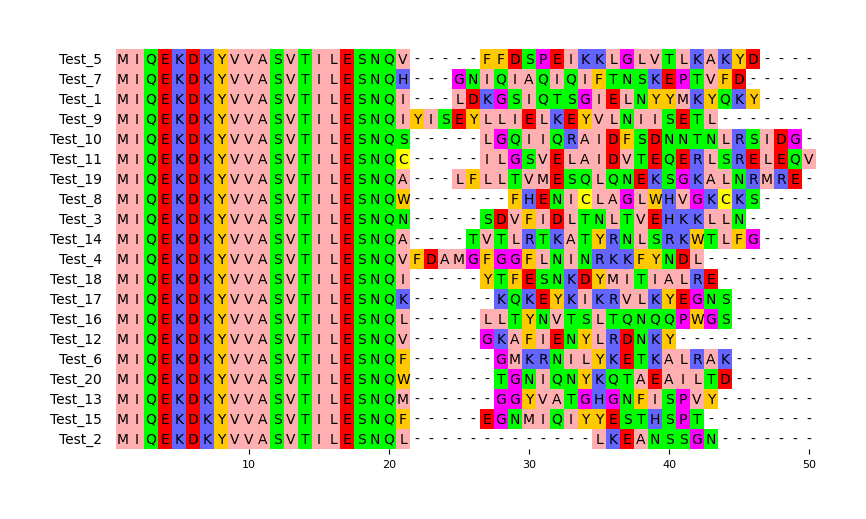

```python
from pymsaviz import MsaViz, get_msa_testdata

mv = MsaViz(alignment)
fig = mv.plotfig()
```

# Protein Structures

`Bio.PDB` is a Biopython module that focuses on working with crystal structures of biological macromolecules. Among other things, Bio.PDB includes a `PDBParser` class that produces a Structure object, which can be used to access the atomic data in the file in a convenient manner. There is limited support for parsing the information contained in the PDB header.

## Reading and writing crystal structure files

### Retreiving a PDB file

First, we can use the [PDBList module](https://biopython.org/docs/1.76/api/Bio.PDB.PDBList.html#Bio.PDB.PDBList.PDBList.retrieve_pdb_file) to quickly access the PDB (Protein Data Bank) server and retreive PDB files. The PDB file in this case is called "pdb1fat.ent", "1fat" is a user defined name for the structure.

```python
from Bio.PDB.PDBList import PDBList

structure_id = "1fat"

# instantiate access to PDB (Protein Data Bank)
pdblist = PDBList()

# fetch structure file from server
pdb_file = pdblist.retrieve_pdb_file(
    pdb_code=structure_id,
    obsolete=False,
    pdir='.',
    file_format='pdb',
    overwrite=False
)
```

```
Structure exists: './pdb1fat.ent'
```

### Reading a PDB file

Next we create a `PDBParser` object:

```python
from Bio.PDB.PDBParser import PDBParser
p = PDBParser(PERMISSIVE=1)
```

The PERMISSIVE flag indicates that a number of common problems (see [problem structures]) associated with PDB files will be ignored (but note that some atoms and/or residues will be missing). If the flag is not present a PDBConstructionException will be generated if any problems are detected during the parse operation.

The Structure object is then produced by letting the `PDBParser` object parse a PDB file:

```python
structure = p.get_structure(structure_id, pdb_file)
structure.header
```

```
{'name': 'phytohemagglutinin-l',
 'head': 'lectin',
 'idcode': '1FAT',
 'deposition_date': '1996-06-12',
 'release_date': '1996-12-23',
 'structure_method': 'x-ray diffraction',
 'resolution': 2.8,
 'structure_reference': ['m.h.dao-thi,t.w.hamelryck,f.poortmans,t.a.voelker, m.j.chrispeels,l.wyns crystallization of glycosylated and nonglycosylated phytohemagglutinin-l proteins v. 24 134 1996 issn 0887-3585 ',
  'm.j.chrispeels,n.v.raikhel lectins, lectin genes, and their role in plant defensplant cell v. 3 1 1991 issn 1040-4651 ',
  'l.m.hoffman,d.d.donaldson characterization of two phaseolus vulgaris phytohemagglutinin genes closely linked on the chromoembo j. v. 4 883 1985 issn 0261-4189 '],
 'journal_reference': 't.w.hamelryck,m.h.dao-thi,f.poortmans,m.j.chrispeels,r.loris the crystallographic structure of phytohemagglutinin-j.biol.chem. v. 271 20479 1996 issn 0021-9258 8702788 10.1074/jbc.271.34.20479 ',
 'author': 'T.Hamelryck,R.Loris',
 'compound': {'1': {'misc': '',
   'molecule': 'phytohemagglutinin-l',
   'chain': 'a, b, c, d',
   'synonym': 'leucoagglutinating phytohemagglutinin, pha-l'}},
 'source': {'1': {'misc': '',
   'organism_scientific': 'phaseolus vulgaris',
   'organism_taxid': '3885',
   'organ': 'seed',
   'other_details': 'purified pha-l was purchased from sigma'}},
 'has_missing_residues': True,
 'missing_residues': [{'model': None,
   'res_name': 'GLY',
   'chain': 'A',
   'ssseq': 37,
   'insertion': None},
  {'model': None,
   'res_name': 'ASP',
   'chain': 'A',
   'ssseq': 234,
   'insertion': None},
  {'model': None,
   'res_name': 'GLU',
   'chain': 'A',
   'ssseq': 235,
   'insertion': None},
  {'model': None,
   'res_name': 'THR',
   'chain': 'A',
```

[output cut: 373 more lines]

```
   'res_name': 'ILE',
   'chain': 'D',
   'ssseq': 251,
   'insertion': None},
  {'model': None,
   'res_name': 'LEU',
   'chain': 'D',
   'ssseq': 252,
   'insertion': None}],
 'biomoltrans': {'1': [['A', 'B', 'C', 'D'],
   '  1.000000  0.000000  0.000000        0.00000            \n',
   '  0.000000  1.000000  0.000000        0.00000            \n',
   '  0.000000  0.000000  1.000000        0.00000            \n']},
 'keywords': 'glycoprotein, plant defense protein, lectin',
 'journal': 'AUTH   T.W.HAMELRYCK,M.H.DAO-THI,F.POORTMANS,M.J.CHRISPEELS,L.WYNS,AUTH 2 R.LORISTITL   THE CRYSTALLOGRAPHIC STRUCTURE OF PHYTOHEMAGGLUTININ-L.REF    J.BIOL.CHEM.                  V. 271 20479 1996REFN                   ISSN 0021-9258PMID   8702788DOI    10.1074/JBC.271.34.20479'}
```

### Visualizing the Structure

```python
import py3Dmol

#First we assign the py3Dmol.view as view
view=py3Dmol.view()
#The following lines are used to add the addModel class
#to read the PDB files of chain B and C
view.addModel(open(pdb_file, 'r').read(),'pdb')
#Zooming into all visualized structures
view.zoomTo()
#Here we set the background color as white
view.setBackgroundColor('white')
#Here we set the visualization style for chain B and C
view.setStyle({'chain':'A'}, {'cartoon': {'color':'yellow'}})
view.setStyle({'chain':'B'}, {'cartoon': {'color':'purple'}})
view.setStyle({'chain':'C'}, {'cartoon': {'color':'blue'}})
view.setStyle({'chain':'D'}, {'cartoon': {'color':'grey'}})
#And we finally visualize the structures using the command below
view.show()
```

[output not shown]